# 利用R語言來計算近年期貨正逆價差

Neil LEE

# 資料來源與計算方式

## 載入模組

```r
library(tidyr) #整理數據使用
library(lubridate) #日期模組
library(data.table) #把df格式轉換為data.table格式，基本上操作方式一樣，但在處理大量資料(萬筆)的時候，速度有明顯差異
library(ggplot2)  #畫圖模組
```

載入檔案之後，因為資料量稍多，先將檔案轉換為data.table格式，以及發現年月日為文字格式，因此把她轉換為日期。以及修改columns欄位名稱。

```r
future_gap = read.csv("期貨正逆價差.csv",stringsAsFactors = FALSE)
future_gap = as.data.table(future_gap)
future_gap$年月日 = ymd(future_gap$年月日) # 將年月日從字串轉換為日期格式
colnames(future_gap) = c("證券代碼","年月日","加權指數收盤價","台指期收盤價") #重新命名欄位名稱
```

接下來我們發現在原始的資料中，數字為文字格式，數字有小豆點，且數據是不對稱的。

```r
head(future_gap)
```

```
##                 證券代碼     年月日 加權指數收盤價 台指期收盤價
## 1:        Y9999 加權指數 2022-03-15      16,926.06
## 2: TX202203 台指 2022/03 2022-03-15                      16,882
## 3: TX202204 台指 2022/04 2022-03-15                      16,825
## 4: TX202205 台指 2022/05 2022-03-15                      16,797
## 5: TX202206 台指 2022/06 2022-03-15                      16,773
## 6: TX202209 台指 2022/09 2022-03-15                      16,190
```

## 資料型態轉換

將逗點取代之後轉換為數字格式。

```r
#取代逗號再把數據從文字轉換成數字
future_gap$加權指數收盤價 = gsub(",","",future_gap$加權指數收盤價)
future_gap$台指期收盤價 = gsub(",","",future_gap$台指期收盤價)
future_gap$加權指數收盤價 = as.numeric(future_gap$加權指數收盤價)
future_gap$台指期收盤價 = as.numeric(future_gap$台指期收盤價)
```

在整理資料時，先將加權指數以及期貨指數分成兩個data.table，再利用merge方法合併起來，形成根據日期的兩個欄位，加權指數在相同日期會合併與複製。 以下先將數據拆分:

```r
#很白癡的方法，因為抓下來的資料很酷，把數據拆成兩部分再用merge 方法合併，
market_closed = future_gap[!(future_gap$加權指數收盤價 == ""),]  #df[row,col]
market_closed = market_closed[,-4]

future_index = future_gap[!(future_gap$台指期收盤價 == ""),]
future_index = future_index[,-3]
```

## 合併資料

利用merge方式以及新增一個價差欄位(價差= 期貨價格 - 加權指數 )

```r
New_future_gap = merge(market_closed,future_index , by = "年月日" ,all = TRUE) #根據年月日合併資料，保留所有數據
New_future_gap$價差 = New_future_gap$台指期收盤價 - New_future_gap$加權指數收盤價 #新增一個欄位做數據加減
```

這樣就完成以下表格惹

```r
head(New_future_gap)
```

```
##        年月日     證券代碼.x 加權指數收盤價            證券代碼.y 台指期收盤價
## 1: 2000-01-04 Y9999 加權指數        8756.55 TX200001 台指 2000/01         8843
## 2: 2000-01-04 Y9999 加權指數        8756.55 TX200002 台指 2000/02         8870
## 3: 2000-01-04 Y9999 加權指數        8756.55 TX200003 台指 2000/03         8899
## 4: 2000-01-04 Y9999 加權指數        8756.55 TX200006 台指 2000/06         8950
## 5: 2000-01-05 Y9999 加權指數        8849.87 TX200001 台指 2000/01         8810
## 6: 2000-01-05 Y9999 加權指數        8849.87 TX200002 台指 2000/02         8860
##      價差
## 1:  86.45
## 2: 113.45
## 3: 142.45
## 4: 193.45
## 5: -39.87
## 6:  10.13
```

## 畫圖以及新增虛擬變數

使用ggplot套件畫圖 以及新增虛擬變數行列方便計算機率值

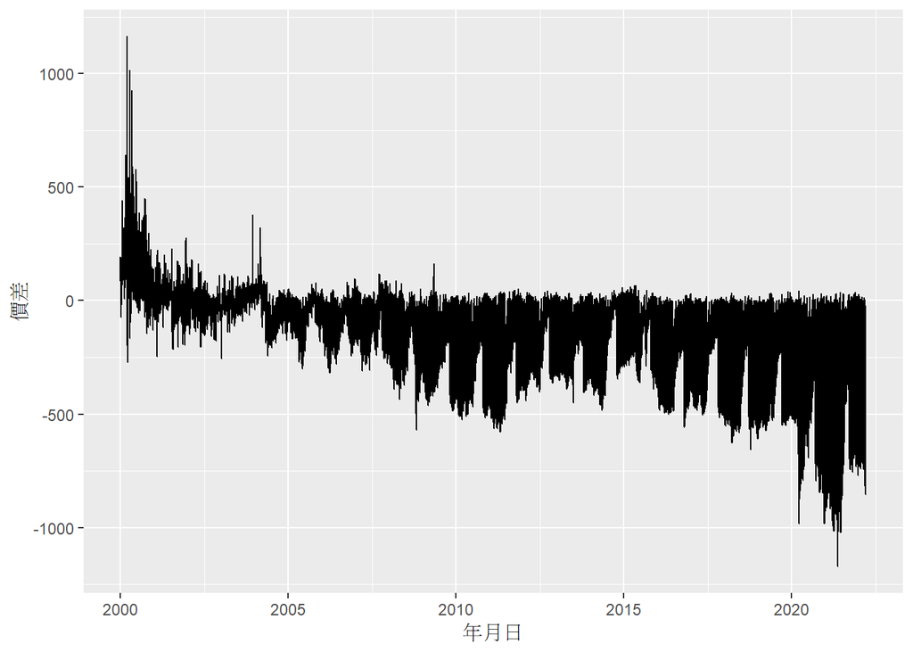

```r
ggplot(New_future_gap, aes(x = 年月日, y = 價差))+ #畫圖
  geom_line(aes(y = 價差))
```

```r
New_future_gap$正價差 = ifelse(New_future_gap$價差>0  ,1,0) #將價差轉換成01虛擬變數
```

最後我們可以將正逆價差的統計值設計成一個函式，方便我們只要輸入日期就可以得知這個日期到2022/3/16出現正逆價差的次數與機率。

```r
gap_prb = function(date){ #設計一個函式，輸入日期之後可以吐出正逆價差次數，以及出現正價差的機率
date = as.character(date)
df = New_future_gap[(New_future_gap$年月日 >= ymd(date)),]
tmp = table(df$正價差)
p = round( mean(df$正價差), digits = 3) #出現正價差的機率
cat("逆價差的次數為: ",tmp[1],"正價差的次數為: ",tmp[2],"正價差的機率為: ",p*100 , "%")
}
gap_prb(20050101)
```

```
## 逆價差的次數為:  19741 正價差的次數為:  2329 正價差的機率為:  10.6 %
```

# 結論與可能的原因